# Homework

## Question 3

Obtain a bootstrap t confidence interval estimate for the correlation statistic in Example 7.2 (law data in bootstrap)

## Answer 3

```r
library(bootstrap)
str(law)
```

```
## 'data.frame':    15 obs. of  2 variables:
##  $ LSAT: num  576 635 558 578 666 580 555 661 651 605 ...
##  $ GPA : num  3.39 3.3 2.81 3.03 3.44 3.07 3 3.43 3.36 3.13 ...
```

```r
B <- 500 # 进行B次重采样(一阶、二阶)
R1 <- numeric(B) # 一阶重采样中相关系数的bootstrap估计
se_R1 <- numeric(B) # 一阶重采样相关系数bootstrap估计的标准差估计
R_hat <- cor(law$LSAT, law$GPA) # 原始样本的相关系数估计
alpha <- 0.05 # 置信区间置信度为95%

# bootstrap
for(i in 1:B){
  # 第i次重采样样本
  id1 <- sample(1:nrow(law), replace = T)
  # 第i次重采样中相关系数的bootstrap估计
  R1[i] <- cor(law$LSAT[id1], law$GPA[id1])

  # 下面需要利用bootstrap估计第i次重采样样本相关系数估计的标准差

  # 对第i次重采样样本进行二阶重采样
  R2 <- numeric(B) # 二阶重采样相关系数的bootstrap估计
  for(j in 1:B){
    id2 <- sample(id1, replace = T)
    R2[j] <- cor(law$LSAT[id2], law$GPA[id2])
  }
  se_R1[i] <- sd(R2)
}

# 分位数估计
Q <- quantile((R1 - R_hat)/se_R1, c(1-alpha/2, alpha/2))
names(Q) <- NULL

# R_hat的标准差的bootstrap估计
se_R_hat <- sd(R1)

# t置信区间的bootstrap估计
R_hat - se_R_hat*Q
```

```
## [1] -0.4941823  0.9657891
```

## ——————————————————————————–

# HW6

## Question 1

Refer to Exercise 7.4. Compute 95% bootstrap confidence intervals for the mean time between failures $1/\lambda$ by the standard normal, basic, percentile, and BCa methods. Compare the intervals and explain why they may differ.

## Answer 1

```r
library(boot)
# 数据
data <- c(3, 5, 7, 18, 43, 85, 91, 98,100, 130, 230, 487)
# 统计量：均值
boot.mean <- function(x, i) mean(x[i])
# 统计量的bootstrap估计
boot.obj <- boot(data = data, statistic = boot.mean, R = 999)
print(boot.obj)
```

```
##
## ORDINARY NONPARAMETRIC BOOTSTRAP
##
##
## Call:
## boot(data = data, statistic = boot.mean, R = 999)
##
##
## Bootstrap Statistics :
##     original    bias    std. error
## t1* 108.0833 -0.890307    37.50011
```

```r
# 四种区间
ci <- boot.ci(boot.obj, type = c('norm', 'basic', 'perc', 'bca'))
print(ci)
```

```
## BOOTSTRAP CONFIDENCE INTERVAL CALCULATIONS
## Based on 999 bootstrap replicates
##
## CALL :
## boot.ci(boot.out = boot.obj, type = c("norm", "basic", "perc",
##     "bca"))
##
## Intervals :
## Level      Normal              Basic
## 95%   ( 35.5, 182.5 )   ( 28.2, 169.2 )
##
## Level     Percentile            BCa
## 95%   ( 46.9, 188.0 )   ( 57.3, 236.5 )
## Calculations and Intervals on Original Scale
## Some BCa intervals may be unstable
```

## Question 2

Refer to Exercise 7.7. Obtain the jackknife estimates of bias and standard error of $\hat{\theta}$.

## Answer 2

```r
library(bootstrap)
# 数据集
str(scor)
```

```
## 'data.frame':    88 obs. of  5 variables:
##  $ mec: num  77 63 75 55 63 53 51 59 62 64 ...
##  $ vec: num  82 78 73 72 63 61 67 70 60 72 ...
##  $ alg: num  67 80 71 63 65 72 65 68 58 60 ...
##  $ ana: num  67 70 66 70 70 64 65 62 62 62 ...
##  $ sta: num  81 81 81 68 63 73 68 56 70 45 ...
```

```r
head(scor)
```

```
##   mec vec alg ana sta
## 1  77  82  67  67  81
## 2  63  78  80  70  81
## 3  75  73  71  66  81
## 4  55  72  63  70  68
## 5  63  63  65  70  63
## 6  53  61  72  64  73
```

```r
# theta_hat估计

# 样本协方差阵(为MLE估计)
sigma <- cor(scor)
# 对样本协方差阵作谱分解
eigen_decompos <- eigen(sigma)
# 求解第一主成分解释的比例
theta_hat <- eigen_decompos[[1]][1]/sum(eigen_decompos[[1]])
theta_hat
```

```
## [1] 0.636196
```

```r
# Jacknife方法
n <- nrow(scor)
theta_jack <- numeric(n)
for(i in 1:n){
  sigma_jack <- cor(scor[-i, ])
  theta_jack[i] <- eigen(sigma_jack)[[1]][1]/sum(eigen(sigma_jack)[[1]])
}
# 偏差的Jacknife估计
bias_jack <- (n-1)*(mean(theta_jack) - theta_hat)
bias_jack
```

```
## [1] -0.0003778535
```

```r
# 标准差的Jacknife估计
sd_jack <- sqrt((n-1)*var(theta_jack))
sd_jack
```

```
## [1] 0.04492281
```

## Question 3

In Example 7.18, leave-one-out (n-fold) cross validation was used to select the best fitting model. Use leave-two-out cross validation to compare the models.

## Answer 3

```r
# 读取并查看数据
library(SA23204171)
data(ironslag)
attach(ironslag)

# leave-two-out cross-validation(n/2 fold CV)
n <- nrow(ironslag)
e1 <- e2 <- e3 <- e4 <- numeric(n)
for(k in 1:(n/2)){
  y <- ironslag$magnetic[-c(2*k-1, 2*k)]
  x <- ironslag$chemical[-c(2*k-1, 2*k)]

  J1 <- lm(y~x)
  yhat1 <- J1$coef[1] + J1$coef[2] * ironslag$chemical[c(2*k-1, 2*k)]
  e1[c(2*k-1, 2*k)] <- ironslag$magnetic[c(2*k-1, 2*k)] - yhat1

  J2 <- lm(y~x + I(x^2))
  yhat2 <- J2$coef[1] + J2$coef[2] * ironslag$chemical[c(2*k-1, 2*k)] +
           J2$coef[3] * ironslag$chemical[c(2*k-1, 2*k)]^2
  e2[c(2*k-1, 2*k)] <- ironslag$magnetic[c(2*k-1, 2*k)] - yhat2

  J3 <- lm(log(y)~x)
  logyhat3 <- J3$coef[1] + J3$coef[2] * ironslag$chemical[c(2*k-1, 2*k)]
  yhat3 <- exp(logyhat3)
  e3[c(2*k-1, 2*k)] <- ironslag$magnetic[c(2*k-1, 2*k)] - yhat3

  J4 <- lm(log(y)~log(x))
  logyhat4 <- J4$coef[1] + J4$coef[2] * log(ironslag$chemical[c(2*k-1, 2*k)])
  yhat4 <- exp(logyhat4)
  e4[c(2*k-1, 2*k)] <- ironslag$magnetic[c(2*k-1, 2*k)] - yhat4
}

c(mean(e1^2), mean(e2^2), mean(e3^2), mean(e4^2))
```

```
## [1]  889.9197  893.4244 1065.4040 1030.5156
```

可以看出此时选择第一个模型最好。

## ——————————————————————————–

# HW7

## Question 1

Prove the Stationarity of M-H sampler Algorithm in continuous situation.

## Answer 1

Proof. 当$r=s$时, 等式显然成立. 当$r \neq s$时, $K(r,s)=\alpha(r,s)g(s|r)$.

$K(r,s)f(r)=\alpha(r,s)g(s|r)f(r)=\begin{cases} f(r)g(s|r)\cdot\frac{f(s)g(r|s)}{f(r)g(s|r)}, & f(s)g(r|s)<f(r)g(s|r) \\ f(r)g(s|r), & f(s)g(r|s)>f(r)g(s|r) \end{cases}$, 从而$K(r,s)f(r)=\begin{cases} f(s)g(r|s), & f(s)g(r|s)<f(r)g(s|r) \\ f(r)g(s|r), & f(s)g(r|s)>f(r)g(s|r) \end{cases}$.

$K(s,r)f(s)=\alpha(s,r)g(r|s)f(s)=\begin{cases} f(s)g(r|s)\cdot\frac{f(r)g(s|r)}{f(s)g(r|s)}, & f(r)g(s|r)<f(s)g(r|s) \\ f(s)g(r|s), & f(r)g(s|r)>f(s)g(r|s) \end{cases}$, 从而$K(s,r)f(s)=\begin{cases} f(s)g(r|s), & f(s)g(r|s)<f(r)g(s|r) \\ f(r)g(s|r), & f(s)g(r|s)>f(r)g(s|r) \end{cases}$.

因此$K(s,r)f(s)=K(r,s)f(r)$, 满足平稳性要求.

## Question 2

Implement the two-sample Cramer-von Mises test for equal distributions as a permutation test. Apply the test to the data in Examples 8.1 and 8.2.

## Answer 2

Cramer-von Mises stat.: $W_2=\frac{mn}{(m+n)^2}\bigg[\sum_{i=1}^n\Big(F_n(x_i) - G_m(x_i)\Big)^2 + \sum_{j=1}^m\Big(F_n(y_j) - G_m(y_j)\Big)^2 \bigg]$

分析例8.1:

```r
# 导入数据
attach(chickwts)
x <- sort(as.vector(weight[feed == "soybean"]))
y <- sort(as.vector(weight[feed == "linseed"]))
detach(chickwts)
str(x); str(y)
```

```
##  num [1:14] 158 171 193 199 230 243 248 248 250 267 ...
```

```
##  num [1:12] 141 148 169 181 203 213 229 244 257 260 ...
```

```r
n <- length(x); m <- length(y)
R <- 999                            # number of replicates
z <- c(x, y)                        # pooled sample
reps <- numeric(R)                  # storage for replicates

ecdf <- function(sample, x){
  # 经验分布函数
  # sample为对应的样本, 为向量
  # x为经验分布函数的自变量, 可以为向量
  res <- numeric(length(x))
  for(i in 1:length(x)){
    res[i] <- mean(sample <= x[i])
  }
  return(res)
}

W_2 <- function(sample1, sample2){
  # Cramer-von Mises统计量
  n <- length(sample1); m <- length(sample2)
  temp1 <- sum((ecdf(sample1, sample1) - ecdf(sample2, sample1))^2)
  temp2 <- sum((ecdf(sample1, sample2) - ecdf(sample2, sample2))^2)
  return(m*n * (temp1 + temp2)/ (m+n)^2)
}

# Permutation test with Cramer-von Mises statistic
W0 <- W_2(x, y)
for (i in 1:R){
  k <- sample(n+m, size = n, replace = F)
  x1 <- z[k]
  y1 <- z[-k]
  reps[i] <- W_2(x1, y1)
}
p <- mean(c(W0, reps) >= W0); p
```

```
## [1] 0.434
```

p值表明检验不显著.

分析例8.2:

```r
attach(chickwts)
x <- sort(as.vector(weight[feed == "sunflower"])) # x发生了改变
y <- sort(as.vector(weight[feed == "linseed"]))
detach(chickwts)
str(x); str(y)
```

```
##  num [1:12] 226 295 297 318 320 322 334 339 340 341 ...
```

```
##  num [1:12] 141 148 169 181 203 213 229 244 257 260 ...
```

```r
n <- length(x); m <- length(y)
R <- 999                            # number of replicates
z <- c(x, y)                        # pooled sample
reps <- numeric(R)                  # storage for replicates

ecdf <- function(sample, x){
  # 经验分布函数
  # sample为对应的样本, 为向量
  # x为经验分布函数的自变量, 可以为向量
  res <- numeric(length(x))
  for(i in 1:length(x)){
    res[i] <- mean(sample <= x[i])
  }
  return(res)
}

W_2 <- function(sample1, sample2){
  # Cramer-von Mises统计量
  n <- length(sample1); m <- length(sample2)
  temp1 <- sum((ecdf(sample1, sample1) - ecdf(sample2, sample1))^2)
  temp2 <- sum((ecdf(sample1, sample2) - ecdf(sample2, sample2))^2)
  return(m*n * (temp1 + temp2)/ (m+n)^2)
}

# Permutation test with Cramer-von Mises statistic
W0 <- W_2(x, y)
for (i in 1:R){
  k <- sample(n+m, size = n, replace = F)
  x1 <- z[k]
  y1 <- z[-k]
  reps[i] <- W_2(x1, y1)
}
p <- mean(c(W0, reps) >= W0); p
```

```
## [1] 0.001
```

p值表明检验显著.

## Question 3

The Count 5 test for equal variances in Section 6.4 is based on the maximum number of extreme points. Example 6.15 shows that the Count 5 criterion is not applicable for unequal sample sizes. Implement a permutation test for equal variance based on the maximum number of extreme points that applies when sample sizes are not necessarily equal.

## Answer 3

```r
# count five statistic
count5 <- function(x, y){
  x1 <- x - mean(x)
  y1 <- y - mean(y)
  x_extreme <- sum(x1 > max(y1)) + sum(x1 < min(y1))
  y_extreme <- sum(y1 > max(x1)) + sum(y1 < min(x1))
  return(max(x_extreme, y_extreme))
}

N <- 50       # repeat the test N times
m <- 50; n <- 80
x <- rnorm(m, 0, 1); y <- rnorm(n, 0, 1.5)
D0 <- count5(x, y)
R <- 1000       # number pf replicates
D <- numeric(R) # storage for relicates
p <- numeric(N) # storage for p value in each repeated test

for (i in 1:N){
  for (j in 1:R){
    k <- sample(m+n, size = m, replace = F)
    x1 <- c(x, y)[k]
    y1 <- c(x, y)[-k]
    D[j] <- count5(x1, y1)
  }
  p[i] <- mean(c(D0, D) >= D0)
}
round(p, 4)
```

```
##  [1] 0.1499 0.1349 0.1439 0.1289 0.1538 0.1449 0.1139 0.1508 0.1379 0.1319
## [11] 0.1249 0.1538 0.1369 0.1508 0.1309 0.1329 0.1359 0.1239 0.1389 0.1508
## [21] 0.1329 0.1429 0.1289 0.1439 0.1538 0.1479 0.1439 0.1558 0.1349 0.1359
## [31] 0.1409 0.1339 0.1229 0.1339 0.1359 0.1369 0.1259 0.1489 0.1459 0.1489
## [41] 0.1349 0.1269 0.1399 0.1489 0.1598 0.1469 0.1449 0.1499 0.1349 0.1339
```

```r
mean(p < 0.05)
```

```
## [1] 0
```

## ——————————————————————————–

# HW8

## Question 1

## Answer 1

```r
intercept <- function(N, b1, b2, b3, f0){
  x1 <- rpois(N, lambda = 1)
  x2 <- rexp(N, rate = 1)
  x3 <- rbinom(N, size = 1, prob = 0.5)

  logit <- function(a){
    t <- exp(a + b1*x1 + b2*x2 + b3*x3)
    p <- t / (t + 1)
    return(mean(p) - f0)
  }

  res <- uniroot(logit, c(-30, 30))
  return(unlist(res)[1:3])
}

N <- 1e6
b1 <- 0; b2 <- 1; b3 <- -1
f0 <- c(0.1, 0.01, 0.001, 0.0001)

intercept(N, b1, b2, b3, f0[1])
```

```
##          root        f.root          iter
## -3.167175e+00  1.188843e-08  1.000000e+01
```

```r
intercept(N, b1, b2, b3, f0[2])
```

```
##          root        f.root          iter
## -6.077767e+00 -1.138390e-07  1.400000e+01
```

```r
intercept(N, b1, b2, b3, f0[3])
```

```
##          root        f.root          iter
## -8.745344e+00  1.698565e-11  1.200000e+01
```

```r
intercept(N, b1, b2, b3, f0[4])
```

```
##          root        f.root          iter
## -1.121787e+01  1.342837e-11  1.200000e+01
```

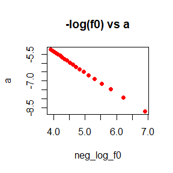

```r
f0 <- seq(0.001, 0.02, 0.001)
a <- numeric(20)
for (i in 1:20){
  a[i] <- intercept(N, b1, b2, b3, f0[i])[1]
}
neg_log_f0 <- -log(f0)
plot(neg_log_f0, a, main = '-log(f0) vs a', col = 'red', pch = 19)
```

## Question 2

Implement a random walk Metropolis sampler for generating the standard Laplace distribution (see Exercise 3.2). For the increment, simulate from a normal distribution. Compare the chains generated when different variances are used for the proposal distribution. Also, compute the acceptance rates of each chain.

## Answer 2

Standard Laplace: $f(x) = \frac12e^{-\vert x\vert},\quad x \in \mathbb{R}$.

```r
RW_Metropolis_Laplace <- function(sigma, x0, N){
  # 用random walk metropolis方法生成标准拉普拉斯随机数
  x <- numeric(N) # 生成的随机游走链的长度
  x[1] <- x0 # 用户给定初始值
  u <- runif(N)
  k <- 0 # 标记拒绝的次数
  for (i in 2:N){
    y <- rnorm(1, x[i-1], sigma) # 提议分布采用正态分布，方差由用户指定
    if (u[i] <= (exp(abs(x[i-1]) - abs(y)))){
      x[i] <- y
    } else{
      x[i] <- x[i-1]
      k <- k + 1
    }
  }
  return(list(x = x, rej_num = k, accept_rate = (N-k)/N))
}

x0 <- 10
N <- 2000
sigma <- c(0.05, 0.5, 2, 8)
rw1 <- RW_Metropolis_Laplace(sigma[1], x0, N)
rw2 <- RW_Metropolis_Laplace(sigma[2], x0, N)
rw3 <- RW_Metropolis_Laplace(sigma[3], x0, N)
rw4 <- RW_Metropolis_Laplace(sigma[4], x0, N)

cat('sigma = 0.05: rej_num is ', rw1$rej_num, ', accept_rate is ', rw1$accept_rate, '\nsigma = 0.5 : rej_num is ', rw2$rej_num, ', accept_rate is ', rw2$accept_rate,
'\nsigma = 2   : rej_num is ', rw3$rej_num, ', accept_rate is ', rw3$accept_rate,
'\nsigma = 8   : rej_num is ', rw4$rej_num, ', accept_rate is ', rw4$accept_rate, sep = '')
```

```
## sigma = 0.05: rej_num is 42, accept_rate is 0.979
## sigma = 0.5 : rej_num is 336, accept_rate is 0.832
## sigma = 2   : rej_num is 974, accept_rate is 0.513
## sigma = 8   : rej_num is 1604, accept_rate is 0.198
```

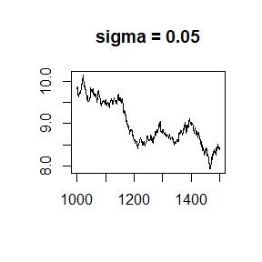

```r
index <- 1000:1500
plot(index, rw1$x[index], type = 'l', main = 'sigma = 0.05', xlab = '', ylab = '')
```

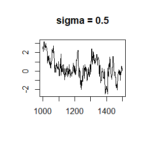

```r
plot(index, rw2$x[index], type = 'l', main = 'sigma = 0.5', xlab = '', ylab = '')
```

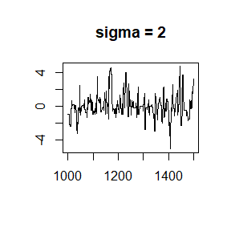

```r
plot(index, rw3$x[index], type = 'l', main = 'sigma = 2', xlab = '', ylab = '')
```

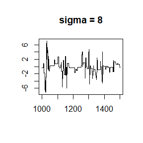

```r
plot(index, rw4$x[index], type = 'l', main = 'sigma = 8', xlab = '', ylab = '')
```

## Question 3

Implement a Gibbs sampler to generate a bivariate normal chain $(X_y,Y_t)$ with zero means, unit standard deviations, and correlation 0.9. Plot the generated sample after discarding a suitable burn-in sample. Fit a simple linear regression model $Y=\beta_0+\beta_1X$ to the sample and check the residuals of the model for normality and constant variance.

## Answer 3

我们用吉布斯采样生成二元正态分布随机数，各参数如题给定。

$\mathbb{E}(X\,\vert\,Y=y)=\mu_1+\Sigma_{12}\Sigma_{22}^{-1}(y-\mu_2)=0+0.9\times1\div1(y-0)=0.9y$,

$Var(X\,\vert\,Y=y)=\Sigma_{11}-\Sigma_{12}\Sigma_{22}^{-1}\Sigma_{21}=(1-\rho^2)\sigma_1^2=(1-0.9^2)\times1^2=0.19$,

于是$f(x\,\vert\,y) \sim N(0.9y,\,0.19)$, $f(y\,\vert\,x)\sim N(0.9x,\,0.19)$.

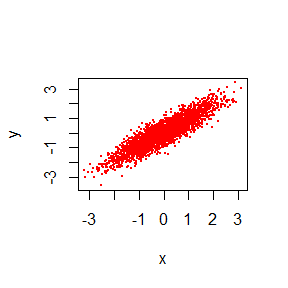

```r
N <- 5000            # length of chain
burn <- 2000         # burn-in length
X <- matrix(0, nrow = N, ncol = 2) # the chain, a bivariate sample

ro <- 0.9                          # correlation
mu1 <- 0; mu2 <- 0                 # mean vector
sigma1 <- 1; sigma2 <- 1           # standard deviation
cond_sigma1 <- sqrt(1-ro^2)*sigma1 # conditional variance of x given y
cond_sigma2 <- sqrt(1-ro^2)*sigma2 # conditional variance of y given x

X[1, ] <- c(mu1, mu2) # initialize
for (i in 2:N){
  y <- X[i-1, 2]
  cond_mu1 <- mu1 + ro * (y-mu2) * sigma1/sigma2 # conditional mean of x given y
  X[i, 1] <- rnorm(1, cond_mu1, cond_sigma1)
  x <- X[i, 1]
  cond_mu2 <- mu2 + ro * (x-mu1) * sigma2/sigma1 # conditional mean of y given x
  X[i, 2] <- rnorm(1, cond_mu2, cond_sigma2)
}

# plot the generated sample after discarding a burn-in period of length 2000
b <- burn + 1
x <- X[b:N, ]
plot(x, main = '', cex = 0.25, xlab = 'x', ylab = 'y', xlim = range(x[, 1]), ylim = range(x[, 2]), pch = 19, col = 'red')
```

```r
# fit a simple linear model
fit <- lm(x[, 2]~x[, 1])
summary(fit)
```

```
##
## Call:
## lm(formula = x[, 2] ~ x[, 1])
##
## Residuals:
##      Min       1Q   Median       3Q      Max
## -1.59565 -0.28486  0.00076  0.28642  1.46339
##
## Coefficients:
##             Estimate Std. Error t value Pr(>|t|)
## (Intercept) 0.008855   0.007926   1.117    0.264
## x[, 1]      0.898140   0.008155 110.136   <2e-16 ***
## ---
## Signif. codes:  0 '***' 0.001 '**' 0.01 '*' 0.05 '.' 0.1 ' ' 1
##
## Residual standard error: 0.434 on 2998 degrees of freedom
## Multiple R-squared:  0.8018, Adjusted R-squared:  0.8018
## F-statistic: 1.213e+04 on 1 and 2998 DF,  p-value: < 2.2e-16
```

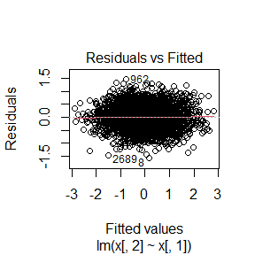

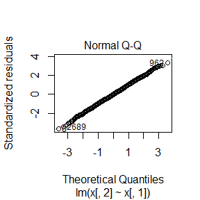

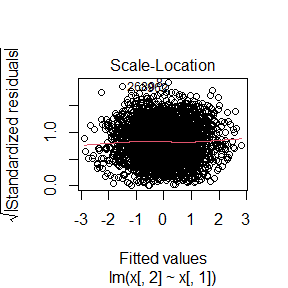

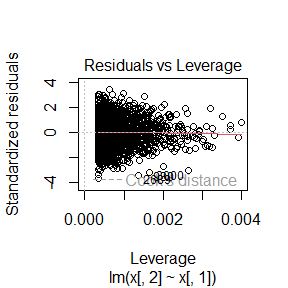

```r
# check the residuals for normality and constant variance
##### 残差正态性良好 #####
##### 残差无非线性趋势，方差齐性良好 #####
plot(fit)
```

## Question 4

Refer to Example 9.1. Use the Gelman-Rubin method to monitor convergence of the chain, and run the chain until the chain has converged approximately to the target distribution according to $\hat{R}<1.2$. (See Exercise 9.9.) Also use the coda [212] package to check for convergence of the chain by the Gelman-Rubin method. Hints: See the help topics for the coda functions gelman.diag, gelman.plot, as.mcmc, and mcmc.list.

## Answer 4

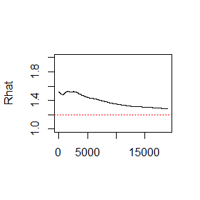

```r
# The Rayleigh(sigma) density
f <- function(x, sigma){
  if (any(x < 0)) return(0)
  stopifnot(sigma > 0)
  return((x/sigma^2) * exp(-x^2/(2*sigma^2)))
}

# Metropolis approach to generate a chain of length n
MH_Rayleigh <- function(n, sigma){
  x <- numeric(n)
  x[1] <- rchisq(1, df = 1)
  u <- runif(n)

  for (i in 2:n){
    xt <- x[i-1]
    y <- rchisq(1, df = xt)
    num <- f(y, sigma) * dchisq(xt, df = y)
    den <- f(xt, sigma) * dchisq(y, df = xt)
    if (u[i] <= num/den){
      x[i] <- y # y is accepted
    } else{
      x[i] <- xt # y is rejected
    }
  }
  return(x)
}

# get R_hat
Gelman_Rubin <- function(psi){
  k <- nrow(psi)
  n <- ncol(psi)

  psi_means <- rowMeans(psi)
  B <- n * var(psi_means)
  W <- mean(apply(psi, 1, var))
  v_hat <- W*(n-1)/n + B/n
  r_hat <- v_hat/W
  return(r_hat)
}

sigma <- 0.5
k <- 4
b <- 1000
N <- 20000
X <- matrix(0, nrow = k, ncol = N)

# generate chains
for (i in 1:k){
  X[i, ] <- MH_Rayleigh(N, sigma)
}

# compute diagnostic statistics
psi <- t(apply(X, 1, cumsum))
rhat <- rep(0, N)
for (i in 1:k){
  psi[i, ] <- psi[i, ]/(1:N)
}
for (j in (b+1):N){
  rhat[j] <- round(Gelman_Rubin(psi[, 1:j]), 3)
}

# plot the sequence of rhat statistics to see when rhat < 1.2
plot(rhat[(b+1):N], type = 'l', xlab = '', ylab = 'Rhat', ylim = c(1, 2))
abline(h = 1.2, lwd = 0.8, col = 'red', lty = 3)
```

## ——————————————————————————–

# HW9

## Question 1

## Answer 1

```r
n <- 10
u <- c(11, 8, 27, 13, 16, 0, 23, 10, 24, 2)
v <- c(12, 9, 28, 14, 17, 1, 24, 11, 25, 3)

# observed data log-likelihood maximization
l_tilta <- function(lambda = 1)  -sum(log(exp(-lambda * u) - exp(-lambda * v)))

library(stats4)
options(warn = -1)
fit <- mle(l_tilta)
fit@coef
```

```
##    lambda
## 0.0719775
```

```r
# EM algorithm
err <- .Machine$double.eps^0.25 # 收敛所容忍的误差
lambda <- 20                    # EM算法迭代初值
flag <- 1                       # 误差标记
iter <- 0                       # 迭代次数

f <- function(x){
  # 迭代公式
  temp <- sum((u*exp(-x*u) - v*exp(-x*v))/(exp(-x*u) - exp(-x*v)))
  return((n * x/(n + x * temp)))
}

while(flag > err){
  flag <- abs(lambda - f(lambda))
  lambda <- f(lambda)
  iter <- iter + 1
}

cat("EM estimate: ", lambda, "\ntimes of iteration: ", iter, sep = '')
```

```
## EM estimate: 0.0719735
## times of iteration: 3
```

## Question 2

In the Morra game, the set of optimal strategies are not changed if a constant is subtracted from every entry of the payoff matrix, or a positive constant is multiplied times every entry of the payoff matrix. However, the simplex algorithm may terminate at a different basic feasible point (also optimal). Compute B <- A + 2, find the solution of game B, and verify that it is one of the extreme points (11.12)–(11.15) of the original game A. Also find the value of game A and game B.

## Answer 2

```r
library(boot)

solve_game <- function(A){
  min_A <- min(A)
  A <- A - min_A
  max_A <- max(A)
  A <- A/max_A
  m <- nrow(A)
  n <- ncol(A)
  it <- n^3
  a <- c(rep(0, m), 1)
  A1 <- -cbind(t(A), rep(-1, n))
  b1 <- rep(0, n)
  A3 <- t(as.matrix(c(rep(1, m), 0)))
  b3 <- 1
  sx <- simplex(a = a, A1 = A1, b1 = b1, A3 = A3, b3 = b3, maxi = T, n.iter = it)

  a <- c(rep(0, n), 1)
  A1 <- cbind(A, rep(-1, m))
  b1 <- rep(0, m)
  A3 <- t(as.matrix(c(rep(1, n), 0)))
  b3 <- 1
  sy <- simplex(a = a, A1 = A1, b1 = b1, A3 = A3, b3 = b3, maxi = F, n.iter = it)

  soln <- list("A" = A * max_A + min_A,
               "x" = sx$soln[1:m],
               "y" = sy$soln[1:n],
               "v" = sx$soln[m+1] * max_A + min_A)
  return(soln)
}

# input the payoff matrix
A <- matrix(c(0,-2,-2,3,0,0,4,0,0,
2,0,0,0,-3,-3,4,0,0,
2,0,0,3,0,0,0,-4,-4,
-3,0,-3,0,4,0,0,5,0,
0,3,0,-4,0,-4,0,5,0,
0,3,0,0,4,0,-5,0,-5,
-4,-4,0,0,0,5,0,0,6,
0,0,4,-5,-5,0,0,0,6,
0,0,4,0,0,5,-6,-6,0), 9, 9)
B <- A + 2

# solve game A and game B
s_A <- solve_game(A)
s_B <- solve_game(B)

# solution of game B
round(cbind(s_B$x, s_B$y), 7)
```

```
##         [,1]      [,2]
## x1 0.0000000 0.0000000
## x2 0.0000000 0.0000000
## x3 0.4098361 0.4098361
## x4 0.0000000 0.0000000
## x5 0.3278689 0.3278689
## x6 0.0000000 0.0000000
## x7 0.2622951 0.2622951
## x8 0.0000000 0.0000000
## x9 0.0000000 0.0000000
```

```r
# value of game A and B
value <- c(s_A$v, s_B$v)
names(value) <- c("A", "B")
cat('\n'); print(value)
```

```
## A B
## 0 2
```

```r
# one of the extreme points
print(c(0, 0, 25/61, 0, 20/61, 0, 16/61, 0, 0))
```

```
## [1] 0.0000000 0.0000000 0.4098361 0.0000000 0.3278689 0.0000000 0.2622951
## [8] 0.0000000 0.0000000
```

```r
# 显然game B的解为game A的一个极值点.
```

## ——————————————————————————–

# HW10

## Question 1

- 2.1.3 Ex.4
- 2.3.1 Ex.1, Ex.2
- 2.4.5 Ex.2, Ex.3
- Page 204 Ex.2
- Page 213 Ex.1

## Answer 1

- 2.1.3 Ex.4

list可以存储不同类型和结构的数据, 如字符型、逻辑型、数值型、矩阵、列表、数据框等, unlist()可以智能地将它们转化为尽可能统一的类型存储在向量中, as.vector()不可以.

- 2.3.1 Ex.1, Ex.2

```r
# Ex.1
v <- c(1, 2, 3)
dim(v)
```

[output not shown]

```r
# Ex.2
x <- matrix(c(1,1,1,1), 2,2)
is.matrix(x)
```

```
## [1] TRUE
```

```r
is.array(x)
```

```
## [1] TRUE
```

- 2.4.5 Ex.2, Ex.3

```r
# Ex.2
d <- data.frame('1'=c(1, 2, 3), '2'=c('a','b','c'), '3'=c(T,T,F), '4'=c(NA,NA,NA))
d
```

```
##   X1 X2    X3 X4
## 1  1  a  TRUE NA
## 2  2  b  TRUE NA
## 3  3  c FALSE NA
```

```r
as.matrix(d)
```

```
##      X1  X2  X3      X4
## [1,] "1" "a" "TRUE"  NA
## [2,] "2" "b" "TRUE"  NA
## [3,] "3" "c" "FALSE" NA
```

```r
# Ex.3
d_nocol <- d[, -c(1,2,3,4)]
d_nocol
```

```
## data frame with 0 columns and 3 rows
```

```r
str(d_nocol)
```

```
## 'data.frame':    3 obs. of  0 variables
```

```r
d_norow <- d[-c(1,2,3), ]
d_norow
```

```
## [1] X1 X2 X3 X4
## <0 rows> (or 0-length row.names)
```

```r
str(d_norow)
```

```
## 'data.frame':    0 obs. of  4 variables:
##  $ X1: num
##  $ X2: chr
##  $ X3: logi
##  $ X4: logi
```

- Page 204 Ex.2

The function below scales a vector so it falls in the range [0, 1]. How would you apply it to every column of a data frame? How would you apply it to every numeric column in a data frame?

```r
scale01 <- function(x) {
  rng <- range(x, na.rm = TRUE)
  (x - rng[1]) / (rng[2] - rng[1])
}

# apply scale01 to every column of a data frame
d1 <- data.frame('1'=c(2,1,3), '2'=c(4,1,6), '3'=c(5,6,9))
d1
```

```
##   X1 X2 X3
## 1  2  4  5
## 2  1  1  6
## 3  3  6  9
```

```r
apply(d1, MARGIN = 2, scale01)
```

```
##       X1  X2   X3
## [1,] 0.5 0.6 0.00
## [2,] 0.0 0.0 0.25
## [3,] 1.0 1.0 1.00
```

```r
# apply scale01 to every numeric column of a data frame
d2 <- data.frame('1'=c(2,1,3), '2'=c(4,1,6), '3'=c('a','b','c'))
d2
```

```
##   X1 X2 X3
## 1  2  4  a
## 2  1  1  b
## 3  3  6  c
```

```r
cbind(as.data.frame(apply(d2[, as.logical(vapply(d2, is.numeric, 2))], MARGIN = 2, scale01)), d2[, !as.logical(vapply(d2, is.numeric, 2)), drop = F])
```

```
##    X1  X2 X3
## 1 0.5 0.6  a
## 2 0.0 0.0  b
## 3 1.0 1.0  c
```

- Page 213 Ex.1

```r
# Compute the standard deviation of every column in a numeric data frame.
d1 <- data.frame('1'=c(2,1,3), '2'=c(4,1,6), '3'=c(5,6,9))
d1
```

```
##   X1 X2 X3
## 1  2  4  5
## 2  1  1  6
## 3  3  6  9
```

```r
vapply(d1, sd, FUN.VALUE = 1)
```

```
##       X1       X2       X3
## 1.000000 2.516611 2.081666
```

```r
# Compute the standard deviation of every numeric column in a mixed data frame.
d2 <- data.frame('1'=c(2,1,3), '2'=c(4,1,6), '3'=c('a','b','c'))
d2
```

```
##   X1 X2 X3
## 1  2  4  a
## 2  1  1  b
## 3  3  6  c
```

```r
vapply(d2[, as.logical(vapply(d2, is.numeric, 1))], sd, FUN.VALUE = 1)
```

```
##       X1       X2
## 1.000000 2.516611
```

## Question 2

Consider the bivariate density
$$f(x,y)
\propto C_n^x\,y^{x+a-1}(1-y)^{n-x+b-1},\quad\quad
x=0,\,1,\,\dots,\,n,\;y \in [0,\,1].$$
For fixed $a,b,n$, the conditional distributions are $B(n,y)$ and $Beta(x+a,n-x+b)$. Use the Gibbs sampler to generate a chain with target joint density $f(x,y)$.

## Answer 2

```r
# settings
Nchain <- 500
a <- 1
b <- 2
n <- 20
thin=20

# gibbs in R
gibbsR <- function(N, thin) {
  mat <- matrix(nrow = N, ncol = 2)
  x <- y <- 0.5
  for (i in 1:N) {
    for (j in 1:thin) {
      x <- rbinom(1, n, y)
      y <- rbeta(1, x+a, n-x+b)
    }
    mat[i, ] <- c(x, y)
  }
  mat
}
```